# A Boolean model of EGFR signalling in adult neurogenesis

Yozlem Bahar

29 May, 2019

The Boolean model of EGFR signaling was generated as a reflection of NSC culture. In this way, we are able to analyze the behavior of pathway components under certain conditions such as proliferation or differentiation. This method therefore allows to generate testable hyphotheses in vitro model.

The work of Samaga *et al.* (2009) has been helpful for the implementation of as they used a boolean model. MANGO database was used to search for genes involved in EGFR pathway and regulating adult neurogenesis Overall *et al.*. (2012).

```
## [1] "Mtorc1"         "Mtorc2"         "diacylglycerol" "Apoptosis"
## [5] "Proliferation"  "Neurogenesis"
```

# Generate a starting state where the input node is also 0

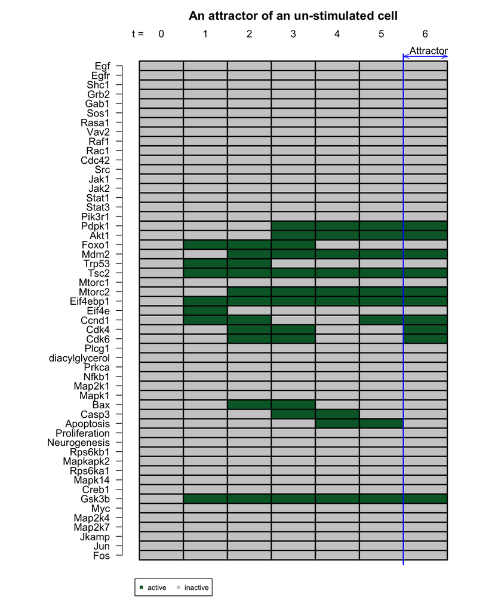

```
##                1 2 3 4 5 6 7
## Fos            0 0 0 0 0 0 0
## Jun            0 0 0 0 0 0 0
## Jkamp          0 0 0 0 0 0 0
## Map2k7         0 0 0 0 0 0 0
## Map2k4         0 0 0 0 0 0 0
## Myc            0 0 0 0 0 0 0
## Gsk3b          0 1 1 1 1 1 1
## Creb1          0 0 0 0 0 0 0
## Mapk14         0 0 0 0 0 0 0
## Rps6ka1        0 0 0 0 0 0 0
## Mapkapk2       0 0 0 0 0 0 0
## Rps6kb1        0 0 0 0 0 0 0
## Neurogenesis   0 0 0 0 0 0 0
## Proliferation  0 0 0 0 0 0 0
## Apoptosis      0 0 0 0 1 1 0
## Casp3          0 0 0 1 1 0 0
## Bax            0 0 1 1 0 0 0
## Mapk1          0 0 0 0 0 0 0
## Map2k1         0 0 0 0 0 0 0
## Nfkb1          0 0 0 0 0 0 0
## Prkca          0 0 0 0 0 0 0
## diacylglycerol 0 0 0 0 0 0 0
## Plcg1          0 0 0 0 0 0 0
## Cdk6           0 0 1 1 0 0 1
## Cdk4           0 0 1 1 0 0 1
## Ccnd1          0 1 1 0 0 1 1
## Eif4e          0 1 0 0 0 0 0
## Eif4ebp1       0 1 1 1 1 1 1
## Mtorc2         0 0 1 1 1 1 1
## Mtorc1         0 0 0 0 0 0 0
## Tsc2           0 1 1 1 1 1 1
## Trp53          0 1 1 0 0 0 0
## Mdm2           0 0 1 1 1 1 1
## Foxo1          0 1 1 1 0 0 0
## Akt1           0 0 0 1 1 1 1
## Pdpk1          0 0 0 1 1 1 1
## Pik3r1         0 0 0 0 0 0 0
## Stat3          0 0 0 0 0 0 0
## Stat1          0 0 0 0 0 0 0
## Jak2           0 0 0 0 0 0 0
## Jak1           0 0 0 0 0 0 0
## Src            0 0 0 0 0 0 0
## Cdc42          0 0 0 0 0 0 0
## Rac1           0 0 0 0 0 0 0
## Raf1           0 0 0 0 0 0 0
## Vav2           0 0 0 0 0 0 0
## Rasa1          0 0 0 0 0 0 0
## Sos1           0 0 0 0 0 0 0
## Gab1           0 0 0 0 0 0 0
## Grb2           0 0 0 0 0 0 0
## Shc1           0 0 0 0 0 0 0
## Egfr           0 0 0 0 0 0 0
## Egf            0 0 0 0 0 0 0
```

# Simulation of proliferation conditions by setting Egf to 1

Assumption: Prkca which is the inhibitor of Egfr is initially inactive

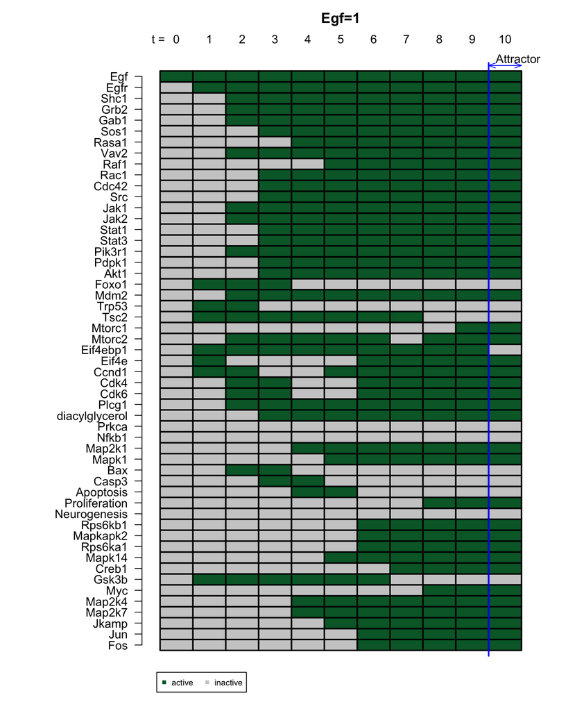

#Robustness Analysis

Robusness analysis was done using a computer-intensive test. This was done because knocking-out single nodes did not help induce perturbation to the network as signaling networks known to be robust. This was also suggested though in vitro experiments as NSCs with TF knockouts showed similar morphology and cell density with the negative control.

In this test, transition robustness of the network was measured in terms of Hamming distance (d).

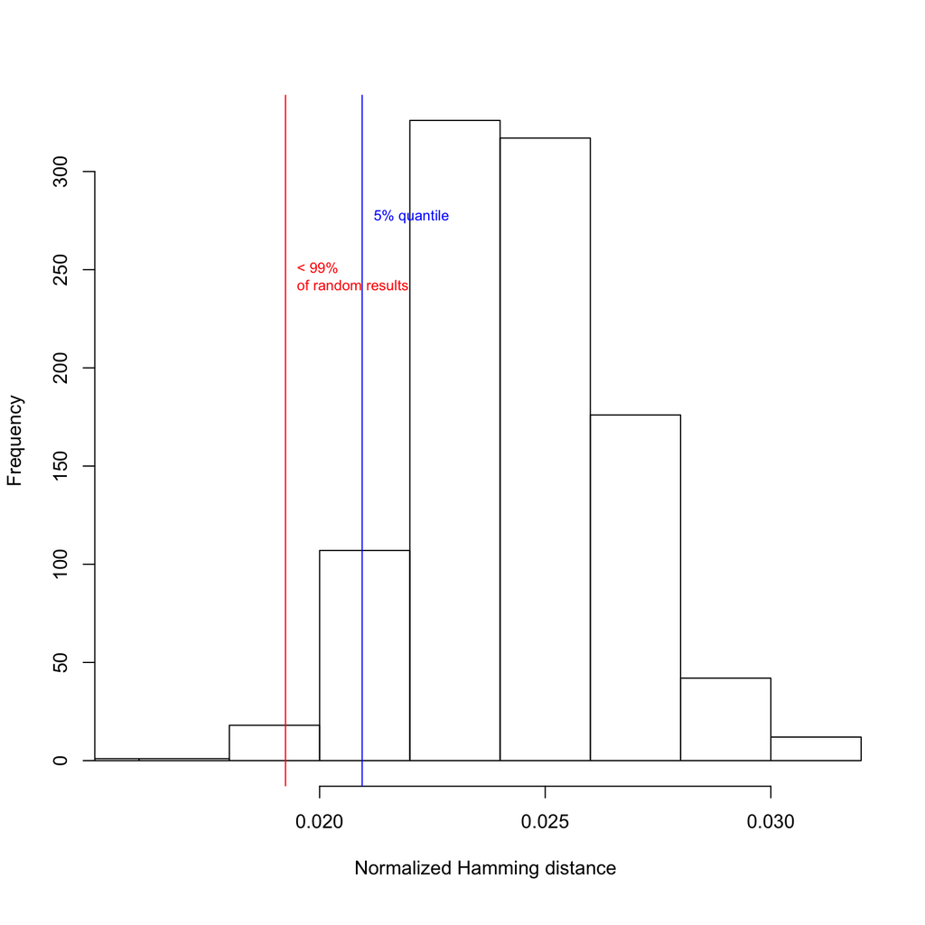

```
## [1] 0.01
```

```
## [1] TRUE
```

# Simulation of differentiation conditions by setting Egf to 0

# Assumption: The inhibitor of Egfr is activated in a negative feedback loop.

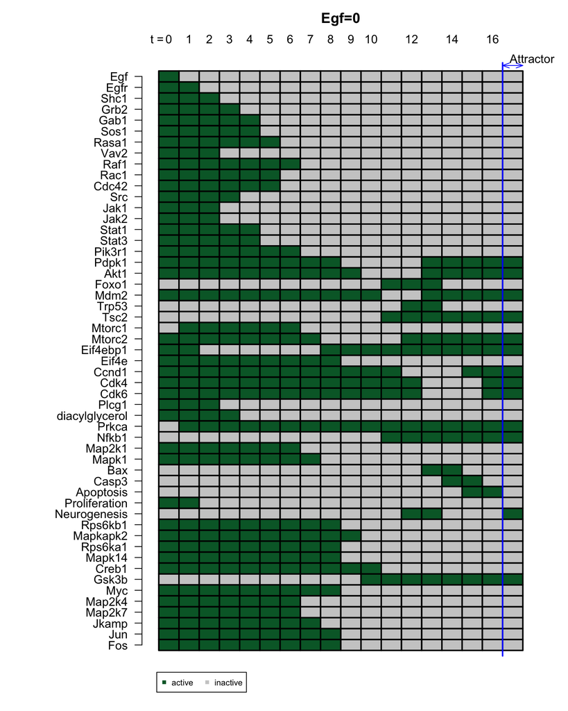

# Knockout Jun under proliferation conditions

[figure not shown]

Overall, R.W., Paszkowski-Rogacz, M., and Kempermann, G. (2012). The Mammalian Adult Neurogenesis Gene Ontology (MANGO) Provides a Structural Framework for Published Information on Genes Regulating Adult Hippocampal Neurogenesis. PLoS ONE *7*.

Samaga, R., Saez-Rodriguez, J., Alexopoulos, L.G., Sorger, P.K., and Klamt, S. (2009). The logic of EGFR/ErbB signaling: Theoretical properties and analysis of high-throughput data. PLoS Computational Biology *5*.